# EcoCluster: Bayesian Clustering using Truncated Stick-Breaking priors

This vignette illustrates three different types of Bayesian clustering methods using truncated stick-breaking priors: mixture models, stochastic block models (SBM), and species archetype models (SAM). We apply these three clustering methods to simulated data to showcase how the number of groups can be successfully recovered.

# Mixture model

We start by generating simulated data:

```r
rm(list=ls(all=TRUE))
set.seed(1)

#general settings
nloc=300 #number of locations
nspp=50  #number of species
ngroup=5 #number of groups

#set parameters
z=sample(1:ngroup,size=nloc,replace=T)         #cluster assignment of each location
phi=matrix(rbeta(ngroup*nspp,1,1),ngroup,nspp) #species composition of each cluster

#generate data
y=matrix(NA,nloc,nspp)
for (i in 1:nloc){
  phi1=phi[z[i],]
  y[i,]=rbinom(nspp,size=1,prob=phi1)
}
colnames(y)=paste0('spp',1:nspp)
rownames(y)=paste0('loc',1:nloc)

head(y[,1:13])
```

```
#>      spp1 spp2 spp3 spp4 spp5 spp6 spp7 spp8 spp9 spp10 spp11 spp12 spp13
#> loc1    0    0    0    0    0    0    0    1    0     0     0     0     0
#> loc2    0    0    1    0    0    0    0    0    0     0     0     0     1
#> loc3    0    0    0    1    0    0    0    1    1     1     0     1     0
#> loc4    1    0    1    1    1    0    1    1    1     1     1     0     0
#> loc5    0    0    1    0    0    0    0    0    1     0     0     0     0
#> loc6    1    0    1    1    0    0    1    1    1     1     1     1     1
```

To obtain posterior samples from the mixture model parameters, we rely on the function `mixture.gibbs.main.func`. The user needs to specify the following arguments:

- `dat`: binary matrix containing the data (rows are locations and columns are species)
- `ngroup`: maximum number of groups
- `ngibbs`: number of iterations for the Gibbs sampler
- `burnin`: number of iterations to be discarded as burn-in.

```r
library('EcoCluster')
ngibbs=1000
res=mixture.gibbs.main.func(dat=y,ngroup=50,ngibbs=ngibbs,burnin=ngibbs/2)
```

```r
str(res)
```

```
#> List of 5
#>  $ phi  : num [1:501, 1:2500] 0.416 0.465 0.514 0.491 0.447 ...
#>  $ theta: num [1:501, 1:50] 0.226 0.196 0.256 0.216 0.251 ...
#>  $ logl : num [1:501] -7536 -7526 -7524 -7533 -7519 ...
#>  $ z    : int [1:501, 1:300] 1 1 1 1 1 1 1 1 1 1 ...
#>  $ gamma: num [1:501] 0.6 0.55 0.7 0.6 0.7 0.75 0.7 0.55 0.8 0.7 ...
```

The output is a list with 5 elements:

- `phi`: probability of observing each species in each group
- `theta`: probability of each location group
- `logl`: log-likelihood
- `z`: cluster assignment of each location
- `gamma`: TSB prior parameter

The graph below with the log-likelihood suggests that this algorithm has successfully converged after discarding the burn-in iterations.

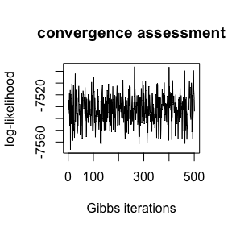

```r
plot(res$logl,type='l',main='convergence assessment',xlab='Gibbs iterations',ylab='log-likelihood')
```

The next graph shows that the algorithm successfully identified the 5 true location groups, with the remaining groups being very small or empty.

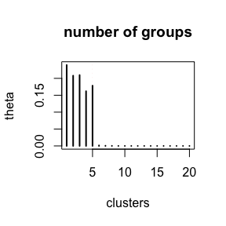

```r
theta=colMeans(res$theta)
plot(theta[1:20],type='h',xlab='clusters',main='number of groups',ylab='theta',lwd=2)
abline(v=5,col='red',lty=3,lwd=0.1)
```

# Stochastic block model

We start by generating simulated data:

```r
rm(list=ls(all=TRUE))
set.seed(1)

#general settings
nloc=300      #number of locations
nspp=50       #number of species
ngroup.loc=5  #number of location groups
ngroup.spp=3  #number of species groups

#set parameters
theta=rep(1/ngroup.loc,ngroup.loc)  #probability of each location group
phi=rep(1/ngroup.spp,ngroup.spp)    #probability of each species group

#probabilities associated with each location and species group
psi=matrix(c(0.05,0.5,0.95,
             0.5,0.05,0.95,
             0.05,0.95,0.5,
             0.5,0.95,0.05,
             0.1,0.5,0.05),ngroup.loc,ngroup.spp,byrow=T)

#get location group and species group assignments
z=sample(1:ngroup.loc,size=nloc,replace=T);
w=sample(1:ngroup.spp,size=nspp,replace=T);

#generate data
y=matrix(NA,nloc,nspp)
for (i in 1:nloc){
  for (j in 1:nspp){
    y[i,j]=rbinom(1,size=1,prob=psi[z[i],w[j]])
  }
}
colnames(y)=paste0('spp',1:nspp)
rownames(y)=paste0('loc',1:nloc)
head(y[,1:13])
```

```
#>      spp1 spp2 spp3 spp4 spp5 spp6 spp7 spp8 spp9 spp10 spp11 spp12 spp13
#> loc1    1    0    0    0    1    1    1    1    1     0     0     0     1
#> loc2    1    0    1    0    0    1    0    1    0     0     1     0     1
#> loc3    1    0    1    1    1    1    0    1    0     1     0     0     0
#> loc4    0    0    1    1    0    1    0    0    0     1     0     0     0
#> loc5    1    1    0    0    0    1    0    1    1     0     1     0     1
#> loc6    0    1    0    1    1    1    0    0    1     0     1     0     0
```

To obtain posterior samples from the stochastic block model parameters, we rely on the function `SBM`. The user needs to specify the following arguments:

- `dat`: binary matrix containing the data (rows are locations and columns are species)
- `ngroup.loc`: maximum number of location groups
- `ngroup.spp`: maximum number of species groups
- `ngibbs`: number of iterations for the Gibbs sampler
- `burnin`: number of iterations to be discarded as burn-in.

```r
library('EcoCluster')
ngibbs=1000
res=SBM(dat=y,ngroup.loc=50,ngroup.spp=50,ngibbs=ngibbs,burnin=ngibbs/2)
```

```r
str(res)
```

```
#> List of 7
#>  $ theta: num [1:501, 1:50] 0.207 0.214 0.172 0.222 0.192 ...
#>  $ phi  : num [1:501, 1:50] 0.384 0.321 0.217 0.373 0.27 ...
#>  $ llk  : num [1:501] -5501 -5507 -5500 -5499 -5504 ...
#>  $ psi  : num [1:501, 1:2500] 0.0718 0.0902 0.0622 0.068 0.0642 ...
#>  $ z    : int [1:501, 1:300] 3 3 3 3 3 3 3 3 3 3 ...
#>  $ w    : int [1:501, 1:50] 2 2 2 2 2 2 2 2 2 2 ...
#>  $ gamma: num [1:501, 1:2] 1 0.85 0.95 0.8 0.9 1 0.95 0.75 0.85 0.85 ...
#>   ..- attr(*, "dimnames")=List of 2
#>   .. ..$ : NULL
#>   .. ..$ : chr [1:2] "gamma.u" "gamma.v"
```

The output is a list with 7 elements:

- `theta`: probability of each location group
- `phi`: probability of each species group
- `llk`: log-likelihood
- `psi`: presence probability for each location group and species group
- `z`: cluster assignment of each location
- `w`: cluster assignment of each species
- `gamma`: TSB prior parameters (one for location groups and the other for species groups)

The graph below with the log-likelihood suggests that this algorithm has successfully converged after discarding the burn-in iterations.

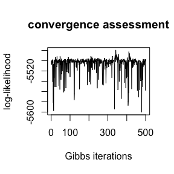

```r
plot(res$llk,type='l',main='convergence assessment',xlab='Gibbs iterations',ylab='log-likelihood')
```

The next two graphs show that the algorithm successfully identified the 5 true location groups and 3 true species groups.

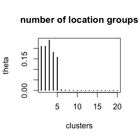

```r
theta=colMeans(res$theta)
plot(theta[1:20],type='h',xlab='clusters',main='number of location groups',ylab='theta',lwd=2)
abline(v=5,col='red',lty=3,lwd=0.1)
```

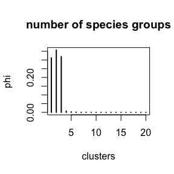

```r
phi=colMeans(res$phi)
plot(phi[1:20],type='h',xlab='clusters',main='number of species groups',ylab='phi',lwd=2)
abline(v=3,col='red',lty=3,lwd=0.1)
```

# Species Archetype model

We start by generating simulated data:

```r
rm(list=ls(all=TRUE))
library('mvtnorm')
set.seed(1)

#general settings
nloc=300   #number of locations
nspp=50    #number of species
nparam=6   #number of covariates
ngroup1=5  #number of species groups

#create design matrix with covariates
xmat=matrix(rnorm(nparam*nloc),nloc,nparam)

#set parameters
alpha=rnorm(nspp,mean=0,sd=0.4) #intercept of each species
tmp=rnorm(nparam*ngroup1)
betas=matrix(tmp,nparam,ngroup1) #slope parameters for each group
cs=sample(1:ngroup1,size=nspp,replace=T) #cluster assignment for each species

#generate data assuming a probit formulation
omega=matrix(NA,nloc,nspp)
for (i in 1:nspp){
  media=alpha[i]+xmat%*%betas[,cs[i]]
  omega[,i]=rnorm(nloc,mean=media,sd=1)
}
y=omega.true=omega
y[omega>0]=1
y[omega<0]=0

colnames(y)=paste0('spp',1:nspp)
rownames(y)=paste0('loc',1:nloc)
head(y[,1:13])
```

```
#>      spp1 spp2 spp3 spp4 spp5 spp6 spp7 spp8 spp9 spp10 spp11 spp12 spp13
#> loc1    0    1    1    1    1    1    1    1    0     1     1     0     1
#> loc2    0    0    0    0    0    0    0    0    1     0     0     1     0
#> loc3    1    0    0    1    0    1    1    1    0     0     1     0     0
#> loc4    0    0    0    1    0    1    1    1    0     0     1     0     0
#> loc5    0    0    0    1    0    0    1    1    0     0     0     0     0
#> loc6    1    1    0    1    1    1    0    1    0     0     1     0     1
```

To obtain posterior samples from the species archetype model parameters, we rely on the function `gibbs.SAM`. The user needs to specify the following arguments:

- `y`: binary matrix containing the data (rows are locations and columns are species)
- `xmat`: matrix containing the predictor variables (rows are locations and columns are predictor variables)
- `ngroups`: maximum number of species groups
- `ngibbs`: number of iterations for the Gibbs sampler
- `burnin`: number of iterations to be discarded as burn-in.

```r
library('EcoCluster')
ngibbs=1000

res=gibbs.SAM(y=y,xmat=xmat,ngroups=50,ngibbs=ngibbs,burnin=ngibbs/2)
```

```r
str(res)
```

```
#> List of 6
#>  $ theta: num [1:501, 1:50] 0.195 0.374 0.21 0.222 0.29 ...
#>  $ logl : num [1:501] -4228 -4226 -4219 -4214 -4217 ...
#>  $ betas: num [1:501, 1:300] 0.158 0.178 0.172 0.187 0.174 ...
#>  $ alpha: num [1:501, 1:50] 0.0641 0.0921 0.1217 0.0938 0.1776 ...
#>  $ cs   : int [1:501, 1:50] 4 4 4 4 4 4 4 4 4 4 ...
#>  $ gamma: num [1:501] 0.9 0.75 0.9 0.8 0.7 0.8 0.85 0.75 0.8 0.65 ...
```

The output is a list with 6 elements:

- `theta`: probability of each species group
- `logl`: log-likelihood
- `betas`: slope parameters for each group
- `cs`: cluster assignment of each species
- `alpha`: intercept of each species
- `gamma`: TSB prior parameter

The graph below with the log-likelihood suggests that this algorithm has successfully converged after discarding the burn-in iterations.

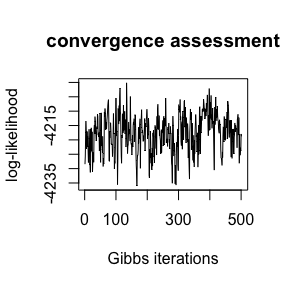

```r
plot(res$logl,type='l',main='convergence assessment',xlab='Gibbs iterations',ylab='log-likelihood')
```

The next graph shows that the algorithm successfully identified the 5 true species groups.

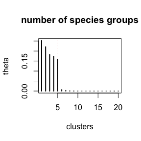

```r
theta=colMeans(res$theta)
plot(theta[1:20],type='h',xlab='clusters',main='number of species groups',ylab='theta',lwd=2)
abline(v=5,col='red',lty=3,lwd=0.1)
```